# Ford GoBike System Data

## Preliminary Wrangling

> The aim of this project is to provide a graphical summary of important features of a data set that includes information about individual rides made in a bike-sharing system by Ford covering the greater San Francisco Bay area.

> The report starts by wrangling the data, then exploring it, and then provide a visual summary for its exceptional features.

```python
#loading the required libraries
import numpy as np
import pandas as pd
import matplotlib.pyplot as plt
import seaborn as sb

%matplotlib inline
```

```python
#loading the dataset
bikes = pd.read_csv('Ford-GoBike-System-Data.txt')
bikes.head()
```

|  | duration_sec | start_time | end_time | start_station_id | start_station_name | start_station_latitude | start_station_longitude | end_station_id | end_station_name | end_station_latitude | end_station_longitude | bike_id | user_type | member_birth_year | member_gender | bike_share_for_all_trip |
| --- | --- | --- | --- | --- | --- | --- | --- | --- | --- | --- | --- | --- | --- | --- | --- | --- |
| 0 | 52185 | 2019-02-28 17:32:10.1450 | 2019-03-01 08:01:55.9750 | 21.0 | Montgomery St BART Station (Market St at 2nd St) | 37.789625 | -122.400811 | 13.0 | Commercial St at Montgomery St | 37.794231 | -122.402923 | 4902 | Customer | 1984.0 | Male | No |
| 1 | 42521 | 2019-02-28 18:53:21.7890 | 2019-03-01 06:42:03.0560 | 23.0 | The Embarcadero at Steuart St | 37.791464 | -122.391034 | 81.0 | Berry St at 4th St | 37.775880 | -122.393170 | 2535 | Customer | NaN | NaN | No |
| 2 | 61854 | 2019-02-28 12:13:13.2180 | 2019-03-01 05:24:08.1460 | 86.0 | Market St at Dolores St | 37.769305 | -122.426826 | 3.0 | Powell St BART Station (Market St at 4th St) | 37.786375 | -122.404904 | 5905 | Customer | 1972.0 | Male | No |
| 3 | 36490 | 2019-02-28 17:54:26.0100 | 2019-03-01 04:02:36.8420 | 375.0 | Grove St at Masonic Ave | 37.774836 | -122.446546 | 70.0 | Central Ave at Fell St | 37.773311 | -122.444293 | 6638 | Subscriber | 1989.0 | Other | No |
| 4 | 1585 | 2019-02-28 23:54:18.5490 | 2019-03-01 00:20:44.0740 | 7.0 | Frank H Ogawa Plaza | 37.804562 | -122.271738 | 222.0 | 10th Ave at E 15th St | 37.792714 | -122.248780 | 4898 | Subscriber | 1974.0 | Male | Yes |

```python
#number of rows and columns
bikes.shape
```

```
(183412, 16)
```

```python
#checking for null values
bikes.isnull().values.any()
```

```
True
```

```python
#deleting null values
bikes.dropna(axis=0, inplace=True)
bikes.isnull().values.any()
```

```
False
```

> Information Summary about the dataset

```python
bikes.info()
```

```
<class 'pandas.core.frame.DataFrame'>
Int64Index: 174952 entries, 0 to 183411
Data columns (total 16 columns):
 #   Column                   Non-Null Count   Dtype
---  ------                   --------------   -----
 0   duration_sec             174952 non-null  int64
 1   start_time               174952 non-null  object
 2   end_time                 174952 non-null  object
 3   start_station_id         174952 non-null  float64
 4   start_station_name       174952 non-null  object
 5   start_station_latitude   174952 non-null  float64
 6   start_station_longitude  174952 non-null  float64
 7   end_station_id           174952 non-null  float64
 8   end_station_name         174952 non-null  object
 9   end_station_latitude     174952 non-null  float64
 10  end_station_longitude    174952 non-null  float64
 11  bike_id                  174952 non-null  int64
 12  user_type                174952 non-null  object
 13  member_birth_year        174952 non-null  float64
 14  member_gender            174952 non-null  object
 15  bike_share_for_all_trip  174952 non-null  object
dtypes: float64(7), int64(2), object(7)
memory usage: 22.7+ MB
```

```python
bikes.describe()
```

|  | duration_sec | start_station_id | start_station_latitude | start_station_longitude | end_station_id | end_station_latitude | end_station_longitude | bike_id | member_birth_year |
| --- | --- | --- | --- | --- | --- | --- | --- | --- | --- |
| count | 174952.000000 | 174952.000000 | 174952.000000 | 174952.000000 | 174952.000000 | 174952.000000 | 174952.000000 | 174952.000000 | 174952.000000 |
| mean | 704.002744 | 139.002126 | 37.771220 | -122.351760 | 136.604486 | 37.771414 | -122.351335 | 4482.587555 | 1984.803135 |
| std | 1642.204905 | 111.648819 | 0.100391 | 0.117732 | 111.335635 | 0.100295 | 0.117294 | 1659.195937 | 10.118731 |
| min | 61.000000 | 3.000000 | 37.317298 | -122.453704 | 3.000000 | 37.317298 | -122.453704 | 11.000000 | 1878.000000 |
| 25% | 323.000000 | 47.000000 | 37.770407 | -122.411901 | 44.000000 | 37.770407 | -122.411647 | 3799.000000 | 1980.000000 |
| 50% | 510.000000 | 104.000000 | 37.780760 | -122.398279 | 101.000000 | 37.781010 | -122.397437 | 4960.000000 | 1987.000000 |
| 75% | 789.000000 | 239.000000 | 37.797320 | -122.283093 | 238.000000 | 37.797673 | -122.286533 | 5505.000000 | 1992.000000 |
| max | 84548.000000 | 398.000000 | 37.880222 | -121.874119 | 398.000000 | 37.880222 | -121.874119 | 6645.000000 | 2001.000000 |

```python
bikes['user_type'].unique()
```

```
array(['Customer', 'Subscriber'], dtype=object)
```

```python
bikes['member_gender'].unique()
```

```
array(['Male', 'Other', 'Female'], dtype=object)
```

```python
bikes.shape
```

```
(174952, 16)
```

```python
bikes['bike_id'].nunique()
```

```
4607
```

```python
bikes['start_station_id'].nunique()
```

```
329
```

```python
bikes['end_station_id'].nunique()
```

```
329
```

### What is the structure of your dataset?

> The Dataset consists of about 175 thousand entries and 16 features which are: Duaration, Start and End Stations' IDs and Names and Locations, Bike ID, User Type, Gender, and Birth Date. The dataset is consisted of mainly of categorical data and all nominal, except for the Duaration.

### What is/are the main feature(s) of interest in your dataset?

> I'm most interested in finding out what features are best for predicting the customers subscription status in the dataset.

### What features in the dataset do you think will help support your investigation into your feature(s) of interest?

> I believe that the Duaration of the rides will affect the users subscription ths most, I am also considering other features like Start and End stations names, Member Gender, and Member Birth Year.

## Univariate Exploration

> In this section, investigation of the distributions of different individual variables is presented.

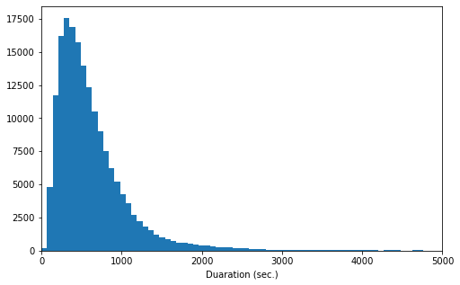

```python
binsize = 70
bins = np.arange(0, bikes['duration_sec'].max()+binsize, binsize)

plt.figure(figsize=[8, 5])
plt.hist(data = bikes, x = 'duration_sec', bins=bins)
plt.xlabel('Duaration (sec.)')
plt.xlim(0, 5000)
plt.show()
```

> The above distribution indicates that the most spent duration is concentrated in the period under 1000 seconds

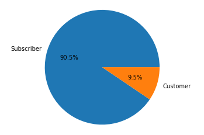

```python
users = bikes['user_type'].value_counts()
plt.pie(users, labels=users.index, autopct='%1.1f%%');
plt.axis('equal');
plt.show();
```

> The ratio between customers and subscribers is 1:9

```python
bikes['start_station_name'].value_counts()
```

```
Market St at 10th St                                         3649
San Francisco Caltrain Station 2  (Townsend St at 4th St)    3408
Berry St at 4th St                                           2952
Montgomery St BART Station (Market St at 2nd St)             2711
Powell St BART Station (Market St at 4th St)                 2620
                                                             ...
Farnam St at Fruitvale Ave                                      9
Parker Ave at McAllister St                                     7
21st Ave at International Blvd                                  4
Palm St at Willow St                                            3
16th St Depot                                                   2
Name: start_station_name, Length: 329, dtype: int64
```

> There are stations that are not common or frequent, so it would be better to see the more interesting stations.

```python
bikes['start_station_name'].value_counts().mean() + (bikes['start_station_name'].value_counts().mean()*0.9)
```

```
1010.361094224924
```

```python
#creating a df with filtered start stations
start_df = bikes.copy()
start_df['start_counts'] = start_df.groupby(['start_station_name'])['start_station_id'].transform('count')
start_df = start_df[start_df['start_counts'] >= 1000] #setting the minimum count value to 1000
start_df.index = range(len(start_df)) #reindexing
start_df.head()
```

|  | duration_sec | start_time | end_time | start_station_id | start_station_name | start_station_latitude | start_station_longitude | end_station_id | end_station_name | end_station_latitude | end_station_longitude | bike_id | user_type | member_birth_year | member_gender | bike_share_for_all_trip | start_counts |
| --- | --- | --- | --- | --- | --- | --- | --- | --- | --- | --- | --- | --- | --- | --- | --- | --- | --- |
| 0 | 52185 | 2019-02-28 17:32:10.1450 | 2019-03-01 08:01:55.9750 | 21.0 | Montgomery St BART Station (Market St at 2nd St) | 37.789625 | -122.400811 | 13.0 | Commercial St at Montgomery St | 37.794231 | -122.402923 | 4902 | Customer | 1984.0 | Male | No | 2711 |
| 1 | 1793 | 2019-02-28 23:49:58.6320 | 2019-03-01 00:19:51.7600 | 93.0 | 4th St at Mission Bay Blvd S | 37.770407 | -122.391198 | 323.0 | Broadway at Kearny | 37.798014 | -122.405950 | 5200 | Subscriber | 1959.0 | Male | No | 1496 |
| 2 | 1049 | 2019-02-28 23:49:47.6990 | 2019-03-01 00:07:17.0250 | 19.0 | Post St at Kearny St | 37.788975 | -122.403452 | 121.0 | Mission Playground | 37.759210 | -122.421339 | 6488 | Subscriber | 1992.0 | Male | No | 1311 |
| 3 | 506 | 2019-02-28 23:56:55.5400 | 2019-03-01 00:05:21.7330 | 44.0 | Civic Center/UN Plaza BART Station (Market St ... | 37.781074 | -122.411738 | 343.0 | Bryant St at 2nd St | 37.783172 | -122.393572 | 5848 | Subscriber | 1993.0 | Male | No | 1476 |
| 4 | 395 | 2019-02-28 23:56:26.8480 | 2019-03-01 00:03:01.9470 | 243.0 | Bancroft Way at College Ave | 37.869360 | -122.254337 | 252.0 | Channing Way at Shattuck Ave | 37.865847 | -122.267443 | 4786 | Subscriber | 1988.0 | Male | No | 1712 |

```python
start_counts = start_df['start_station_name'].value_counts()
start_counts
```

```
Market St at 10th St                                               3649
San Francisco Caltrain Station 2  (Townsend St at 4th St)          3408
Berry St at 4th St                                                 2952
Montgomery St BART Station (Market St at 2nd St)                   2711
Powell St BART Station (Market St at 4th St)                       2620
San Francisco Caltrain (Townsend St at 4th St)                     2577
San Francisco Ferry Building (Harry Bridges Plaza)                 2541
Howard St at Beale St                                              2216
Steuart St at Market St                                            2191
Powell St BART Station (Market St at 5th St)                       2144
The Embarcadero at Sansome St                                      1975
Bancroft Way at Telegraph Ave                                      1761
Bancroft Way at College Ave                                        1712
2nd St at Townsend St                                              1702
Beale St at Harrison St                                            1678
3rd St at Townsend St                                              1675
Embarcadero BART Station (Beale St at Market St)                   1646
4th St at Mission Bay Blvd S                                       1496
Townsend St at 7th St                                              1479
Civic Center/UN Plaza BART Station (Market St at McAllister St)    1476
The Embarcadero at Steuart St                                      1420
Downtown Berkeley BART                                             1322
Post St at Kearny St                                               1311
4th St at 16th St                                                  1274
Howard St at 8th St                                                1257
19th Street BART Station                                           1231
Esprit Park                                                        1226
Rhode Island St at 17th St                                         1224
Hearst Ave at Euclid Ave                                           1176
8th St at Brannan St                                               1154
Folsom St at 3rd St                                                1145
Spear St at Folsom St                                              1113
Laguna St at Hayes St                                              1104
Bryant St at 2nd St                                                1099
Union Square (Powell St at Post St)                                1098
8th St at Ringold St                                               1086
5th St at Folsom                                                   1076
San Francisco Public Library (Grove St at Hyde St)                 1034
Name: start_station_name, dtype: int64
```

```python
start_order = start_counts.index #setting the xticks of the graph in order
start_order
```

```
Index(['Market St at 10th St',
       'San Francisco Caltrain Station 2  (Townsend St at 4th St)',
       'Berry St at 4th St',
       'Montgomery St BART Station (Market St at 2nd St)',
       'Powell St BART Station (Market St at 4th St)',
       'San Francisco Caltrain (Townsend St at 4th St)',
       'San Francisco Ferry Building (Harry Bridges Plaza)',
       'Howard St at Beale St', 'Steuart St at Market St',
       'Powell St BART Station (Market St at 5th St)',
       'The Embarcadero at Sansome St', 'Bancroft Way at Telegraph Ave',
       'Bancroft Way at College Ave', '2nd St at Townsend St',
       'Beale St at Harrison St', '3rd St at Townsend St',
       'Embarcadero BART Station (Beale St at Market St)',
       '4th St at Mission Bay Blvd S', 'Townsend St at 7th St',
       'Civic Center/UN Plaza BART Station (Market St at McAllister St)',
       'The Embarcadero at Steuart St', 'Downtown Berkeley BART',
       'Post St at Kearny St', '4th St at 16th St', 'Howard St at 8th St',
       '19th Street BART Station', 'Esprit Park', 'Rhode Island St at 17th St',
       'Hearst Ave at Euclid Ave', '8th St at Brannan St',
       'Folsom St at 3rd St', 'Spear St at Folsom St', 'Laguna St at Hayes St',
       'Bryant St at 2nd St', 'Union Square (Powell St at Post St)',
       '8th St at Ringold St', '5th St at Folsom',
       'San Francisco Public Library (Grove St at Hyde St)'],
      dtype='object')
```

```python
max_start_count = start_counts[0] #the maximum count of the highest station
max_start_count
```

```
3649
```

```python
n_start = start_counts.sum() #total number of stations count
n_start
```

```
64959
```

```python
max_start_prop = max_start_count / n_start #maximum proportion value
max_start_prop
```

```
0.056173894302560076
```

```python
start_tick_props = np.arange(0, max_start_prop, 0.01) #yticks proportions values
start_tick_props
```

```
array([0.  , 0.01, 0.02, 0.03, 0.04, 0.05])
```

```python
start_tick_names = ['{:0.2f}'.format(v) for v in start_tick_props] #setting yticks
start_tick_names
```

```
['0.00', '0.01', '0.02', '0.03', '0.04', '0.05']
```

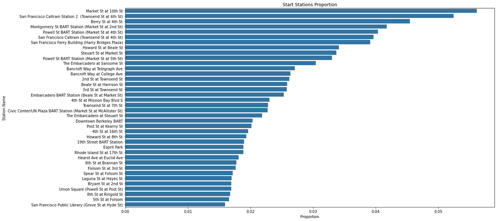

```python
base_color = sb.color_palette()[0]
plt.figure(figsize=[18, 10])
sb.countplot(data=start_df, y='start_station_name', color=base_color, order=start_order);
plt.xticks(start_tick_props * n_start, start_tick_names)
plt.xlabel('Proportion');
plt.ylabel('Station Name');
plt.title('Start Stations Proportion');
```

> It appears that the most three common stations are: Market St, San Francisco Caltrain Station 2, and Berry St

```python
bikes['end_station_name'].value_counts()
```

```
San Francisco Caltrain Station 2  (Townsend St at 4th St)    4624
Market St at 10th St                                         3709
Montgomery St BART Station (Market St at 2nd St)             3461
San Francisco Ferry Building (Harry Bridges Plaza)           3151
San Francisco Caltrain (Townsend St at 4th St)               2870
                                                             ...
Parker Ave at McAllister St                                     9
Palm St at Willow St                                            7
16th St Depot                                                   6
21st Ave at International Blvd                                  5
Willow St at Vine St                                            5
Name: end_station_name, Length: 329, dtype: int64
```

> Just like the above case of the start station, it would be better to visualize only the most interesting stations.

```python
bikes['end_station_name'].value_counts().mean() + (bikes['end_station_name'].value_counts().mean()*0.9)
```

```
1010.361094224924
```

```python
end_df = bikes.copy()
end_df['end_counts'] = end_df.groupby(['end_station_name'])['end_station_id'].transform('count')
end_df = end_df[end_df['end_counts'] >= 1000]
end_df.index = range(len(end_df))
end_df.head()
```

|  | duration_sec | start_time | end_time | start_station_id | start_station_name | start_station_latitude | start_station_longitude | end_station_id | end_station_name | end_station_latitude | end_station_longitude | bike_id | user_type | member_birth_year | member_gender | bike_share_for_all_trip | end_counts |
| --- | --- | --- | --- | --- | --- | --- | --- | --- | --- | --- | --- | --- | --- | --- | --- | --- | --- |
| 0 | 61854 | 2019-02-28 12:13:13.2180 | 2019-03-01 05:24:08.1460 | 86.0 | Market St at Dolores St | 37.769305 | -122.426826 | 3.0 | Powell St BART Station (Market St at 4th St) | 37.786375 | -122.404904 | 5905 | Customer | 1972.0 | Male | No | 2854 |
| 1 | 208 | 2019-02-28 23:59:18.5480 | 2019-03-01 00:02:47.2280 | 349.0 | Howard St at Mary St | 37.781010 | -122.405666 | 60.0 | 8th St at Ringold St | 37.774520 | -122.409449 | 6361 | Subscriber | 1993.0 | Male | Yes | 1000 |
| 2 | 385 | 2019-02-28 23:49:24.3990 | 2019-02-28 23:55:50.2840 | 6.0 | The Embarcadero at Sansome St | 37.804770 | -122.403234 | 15.0 | San Francisco Ferry Building (Harry Bridges Pl... | 37.795392 | -122.394203 | 6531 | Customer | 2000.0 | Male | No | 3151 |
| 3 | 223 | 2019-02-28 23:49:27.0270 | 2019-02-28 23:53:10.5350 | 28.0 | The Embarcadero at Bryant St | 37.787168 | -122.388098 | 50.0 | 2nd St at Townsend St | 37.780526 | -122.390288 | 6267 | Customer | 1993.0 | Male | No | 1667 |
| 4 | 346 | 2019-02-28 23:40:56.0750 | 2019-02-28 23:46:42.4830 | 10.0 | Washington St at Kearny St | 37.795393 | -122.404770 | 19.0 | Post St at Kearny St | 37.788975 | -122.403452 | 6488 | Subscriber | 1992.0 | Male | No | 1366 |

```python
end_counts = end_df['end_station_name'].value_counts()
end_counts
```

```
San Francisco Caltrain Station 2  (Townsend St at 4th St)          4624
Market St at 10th St                                               3709
Montgomery St BART Station (Market St at 2nd St)                   3461
San Francisco Ferry Building (Harry Bridges Plaza)                 3151
San Francisco Caltrain (Townsend St at 4th St)                     2870
Powell St BART Station (Market St at 4th St)                       2854
Berry St at 4th St                                                 2782
The Embarcadero at Sansome St                                      2341
Steuart St at Market St                                            2264
Powell St BART Station (Market St at 5th St)                       2153
Howard St at Beale St                                              1970
Beale St at Harrison St                                            1780
Bancroft Way at Telegraph Ave                                      1780
Civic Center/UN Plaza BART Station (Market St at McAllister St)    1733
2nd St at Townsend St                                              1667
3rd St at Townsend St                                              1628
Embarcadero BART Station (Beale St at Market St)                   1622
4th St at Mission Bay Blvd S                                       1590
Townsend St at 7th St                                              1440
The Embarcadero at Steuart St                                      1414
19th Street BART Station                                           1392
Post St at Kearny St                                               1366
Downtown Berkeley BART                                             1321
Rhode Island St at 17th St                                         1271
8th St at Brannan St                                               1270
Folsom St at 3rd St                                                1247
Howard St at 8th St                                                1216
Esprit Park                                                        1182
4th St at 16th St                                                  1135
Spear St at Folsom St                                              1116
Division St at Potrero Ave                                         1107
Bancroft Way at College Ave                                        1073
5th St at Folsom                                                   1072
MacArthur BART Station                                             1068
Laguna St at Hayes St                                              1068
16th St Mission BART Station 2                                     1049
8th St at Ringold St                                               1000
Name: end_station_name, dtype: int64
```

```python
end_order = end_counts.index
end_order
```

```
Index(['San Francisco Caltrain Station 2  (Townsend St at 4th St)',
       'Market St at 10th St',
       'Montgomery St BART Station (Market St at 2nd St)',
       'San Francisco Ferry Building (Harry Bridges Plaza)',
       'San Francisco Caltrain (Townsend St at 4th St)',
       'Powell St BART Station (Market St at 4th St)', 'Berry St at 4th St',
       'The Embarcadero at Sansome St', 'Steuart St at Market St',
       'Powell St BART Station (Market St at 5th St)', 'Howard St at Beale St',
       'Beale St at Harrison St', 'Bancroft Way at Telegraph Ave',
       'Civic Center/UN Plaza BART Station (Market St at McAllister St)',
       '2nd St at Townsend St', '3rd St at Townsend St',
       'Embarcadero BART Station (Beale St at Market St)',
       '4th St at Mission Bay Blvd S', 'Townsend St at 7th St',
       'The Embarcadero at Steuart St', '19th Street BART Station',
       'Post St at Kearny St', 'Downtown Berkeley BART',
       'Rhode Island St at 17th St', '8th St at Brannan St',
       'Folsom St at 3rd St', 'Howard St at 8th St', 'Esprit Park',
       '4th St at 16th St', 'Spear St at Folsom St',
       'Division St at Potrero Ave', 'Bancroft Way at College Ave',
       '5th St at Folsom', 'MacArthur BART Station', 'Laguna St at Hayes St',
       '16th St Mission BART Station 2', '8th St at Ringold St'],
      dtype='object')
```

```python
max_end_count = end_counts[0]
max_end_count
```

```
4624
```

```python
n_end = end_counts.sum()
n_end
```

```
66786
```

```python
max_end_prop = max_end_count / n_end
max_end_prop
```

```
0.06923606743928368
```

```python
end_tick_props = np.arange(0, max_end_prop, 0.01)
end_tick_props
```

```
array([0.  , 0.01, 0.02, 0.03, 0.04, 0.05, 0.06])
```

```python
end_tick_names = ['{:0.2f}'.format(v) for v in end_tick_props]
end_tick_names
```

```
['0.00', '0.01', '0.02', '0.03', '0.04', '0.05', '0.06']
```

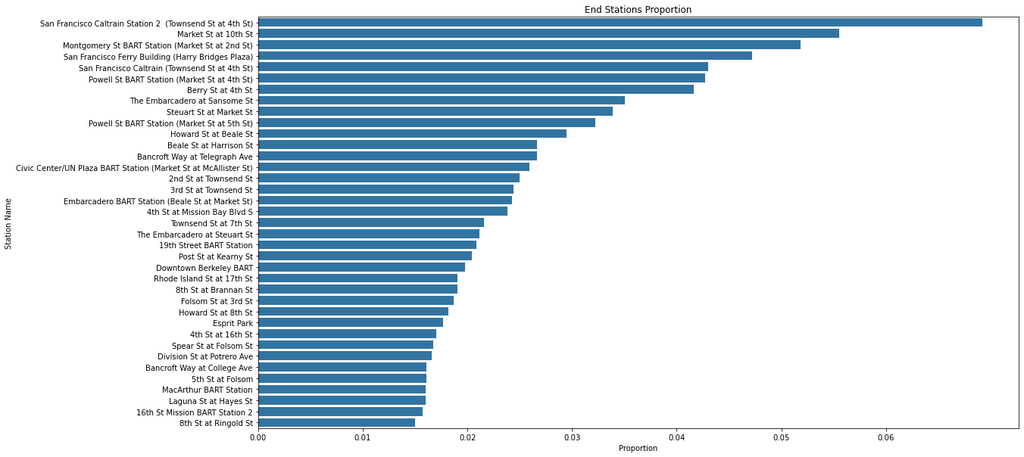

```python
plt.figure(figsize=[18, 10])
sb.countplot(data=end_df, y='end_station_name', color=base_color, order=end_order);
plt.xticks(end_tick_props * n_end, end_tick_names)
plt.xlabel('Proportion');
plt.ylabel('Station Name');
plt.title('End Stations Proportion');
```

> It appears that the most three common stations are: San Francisco Caltrain Station 2, Market St, and Montgomery St BART

```python
years_df = bikes.copy()
years_df['year_counts'] = years_df.groupby(['member_birth_year'])['bike_id'].transform('count')
years_df.head()
```

|  | duration_sec | start_time | end_time | start_station_id | start_station_name | start_station_latitude | start_station_longitude | end_station_id | end_station_name | end_station_latitude | end_station_longitude | bike_id | user_type | member_birth_year | member_gender | bike_share_for_all_trip | year_counts |
| --- | --- | --- | --- | --- | --- | --- | --- | --- | --- | --- | --- | --- | --- | --- | --- | --- | --- |
| 0 | 52185 | 2019-02-28 17:32:10.1450 | 2019-03-01 08:01:55.9750 | 21.0 | Montgomery St BART Station (Market St at 2nd St) | 37.789625 | -122.400811 | 13.0 | Commercial St at Montgomery St | 37.794231 | -122.402923 | 4902 | Customer | 1984.0 | Male | No | 6557 |
| 2 | 61854 | 2019-02-28 12:13:13.2180 | 2019-03-01 05:24:08.1460 | 86.0 | Market St at Dolores St | 37.769305 | -122.426826 | 3.0 | Powell St BART Station (Market St at 4th St) | 37.786375 | -122.404904 | 5905 | Customer | 1972.0 | Male | No | 1909 |
| 3 | 36490 | 2019-02-28 17:54:26.0100 | 2019-03-01 04:02:36.8420 | 375.0 | Grove St at Masonic Ave | 37.774836 | -122.446546 | 70.0 | Central Ave at Fell St | 37.773311 | -122.444293 | 6638 | Subscriber | 1989.0 | Other | No | 8967 |
| 4 | 1585 | 2019-02-28 23:54:18.5490 | 2019-03-01 00:20:44.0740 | 7.0 | Frank H Ogawa Plaza | 37.804562 | -122.271738 | 222.0 | 10th Ave at E 15th St | 37.792714 | -122.248780 | 4898 | Subscriber | 1974.0 | Male | Yes | 2633 |
| 5 | 1793 | 2019-02-28 23:49:58.6320 | 2019-03-01 00:19:51.7600 | 93.0 | 4th St at Mission Bay Blvd S | 37.770407 | -122.391198 | 323.0 | Broadway at Kearny | 37.798014 | -122.405950 | 5200 | Subscriber | 1959.0 | Male | No | 624 |

```python
years_df['member_birth_year'].min()
```

```
1878.0
```

> This entery seems to be an error, it will be assumed that it was meant to be 1978 instead of 1878 and replaced.

```python
years_df.loc[years_df['member_birth_year'] == years_df['member_birth_year'].min()]
```

|  | duration_sec | start_time | end_time | start_station_id | start_station_name | start_station_latitude | start_station_longitude | end_station_id | end_station_name | end_station_latitude | end_station_longitude | bike_id | user_type | member_birth_year | member_gender | bike_share_for_all_trip | year_counts |
| --- | --- | --- | --- | --- | --- | --- | --- | --- | --- | --- | --- | --- | --- | --- | --- | --- | --- |
| 27370 | 1474 | 2019-02-25 09:28:42.1610 | 2019-02-25 09:53:17.0680 | 15.0 | San Francisco Ferry Building (Harry Bridges Pl... | 37.795392 | -122.394203 | 386.0 | 24th St at Bartlett St | 37.752105 | -122.419724 | 6436 | Customer | 1878.0 | Female | No | 1 |

```python
years_df['member_birth_year'][27370] = 1978
years_df['member_birth_year'].min()
```

```
1900.0
```

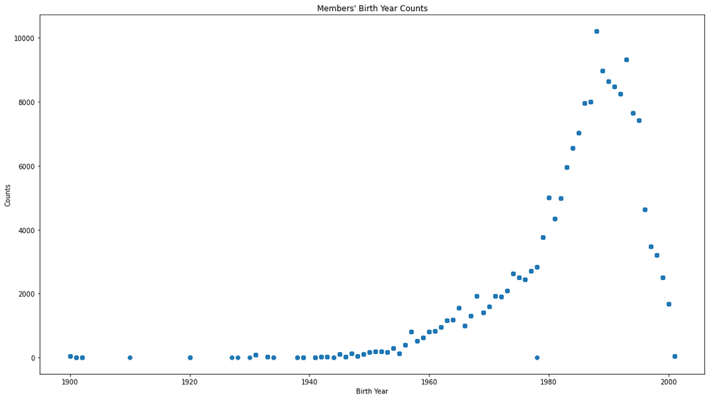

```python
plt.figure(figsize=[18, 10])
plt.scatter(data=years_df, x='member_birth_year', y='year_counts', color=base_color);
plt.xlabel('Birth Year');
plt.ylabel('Counts')
plt.title("Members' Birth Year Counts");
```

> The plot shows that the range with the most concentrated number of users is in the years between 1980s and 1990s

> Checking if the same error is present in the other dfs to fix it.

```python
start_df.loc[start_df['member_birth_year'] == start_df['member_birth_year'].min()]
```

|  | duration_sec | start_time | end_time | start_station_id | start_station_name | start_station_latitude | start_station_longitude | end_station_id | end_station_name | end_station_latitude | end_station_longitude | bike_id | user_type | member_birth_year | member_gender | bike_share_for_all_trip | start_counts |
| --- | --- | --- | --- | --- | --- | --- | --- | --- | --- | --- | --- | --- | --- | --- | --- | --- | --- |
| 10536 | 1474 | 2019-02-25 09:28:42.1610 | 2019-02-25 09:53:17.0680 | 15.0 | San Francisco Ferry Building (Harry Bridges Pl... | 37.795392 | -122.394203 | 386.0 | 24th St at Bartlett St | 37.752105 | -122.419724 | 6436 | Customer | 1878.0 | Female | No | 2541 |

```python
start_df['member_birth_year'][10536] = 1978
start_df['member_birth_year'].min() #checking if the minimum value is updated
```

```
1900.0
```

```python
end_df['member_birth_year'].min()
```

```
1900.0
```

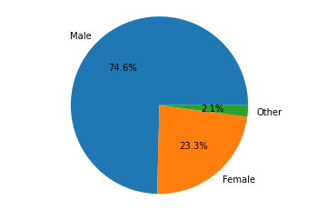

```python
gender = bikes['member_gender'].value_counts()
plt.pie(gender, labels=gender.index, autopct='%1.1f%%');
plt.axis('equal');
plt.show();
```

> The pie chart above indicates that males represent the highest portion of users, which is three quarters.

### Discuss the distribution(s) of your variable(s) of interest. Were there any unusual points? Did you need to perform any transformations?

> The dataset needed a few wrangling, there was some null values and false input data, but they were not much. The distribustions suggests the following:

> > The most spent duration is concentrated in the period under 1000 seconds

> > The most three common start stations are: Market St, San Francisco Caltrain Station 2, and Berry St

> > The most three common stations are: San Francisco Caltrain Station 2, Market St, and Montgomery St BART

> > The most common users are born between the years 1980s and 1990s

> > The ratio between customers and subscribers is 1:9

> > Males represent three quarters of the users

## Bivariate Exploration

> This section investigates relationships between pairs of variables, speciaally with the duration feature.

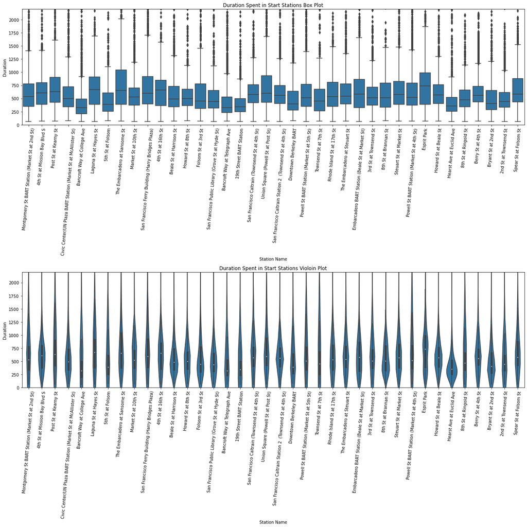

```python
#plotting a violin and box plot for the start stations duration
plt.figure(figsize=[18, 18])
plt.subplot(2, 1, 1)
sb.boxplot(data=start_df, x='start_station_name', y='duration_sec', color=base_color)
plt.ylim(0, 2200)
plt.xticks(rotation=85);
plt.xlabel('Station Name');
plt.ylabel('Duration');
plt.title('Duration Spent in Start Stations Box Plot');

plt.subplot(2, 1, 2)
sb.violinplot(data=start_df, x='start_station_name', y='duration_sec', color=base_color)
plt.ylim(0, 2200)
plt.xticks(rotation=85);
plt.xlabel('Station Name');
plt.ylabel('Duration');
plt.title('Duration Spent in Start Stations Violoin Plot');


plt.tight_layout()
```

> From the box plot it can be deduced that The Embarcadero had the highest IQR in terms of duration

> From the violin plot it can be deduced that Hearst Ave had the highest frequency in terms of duration

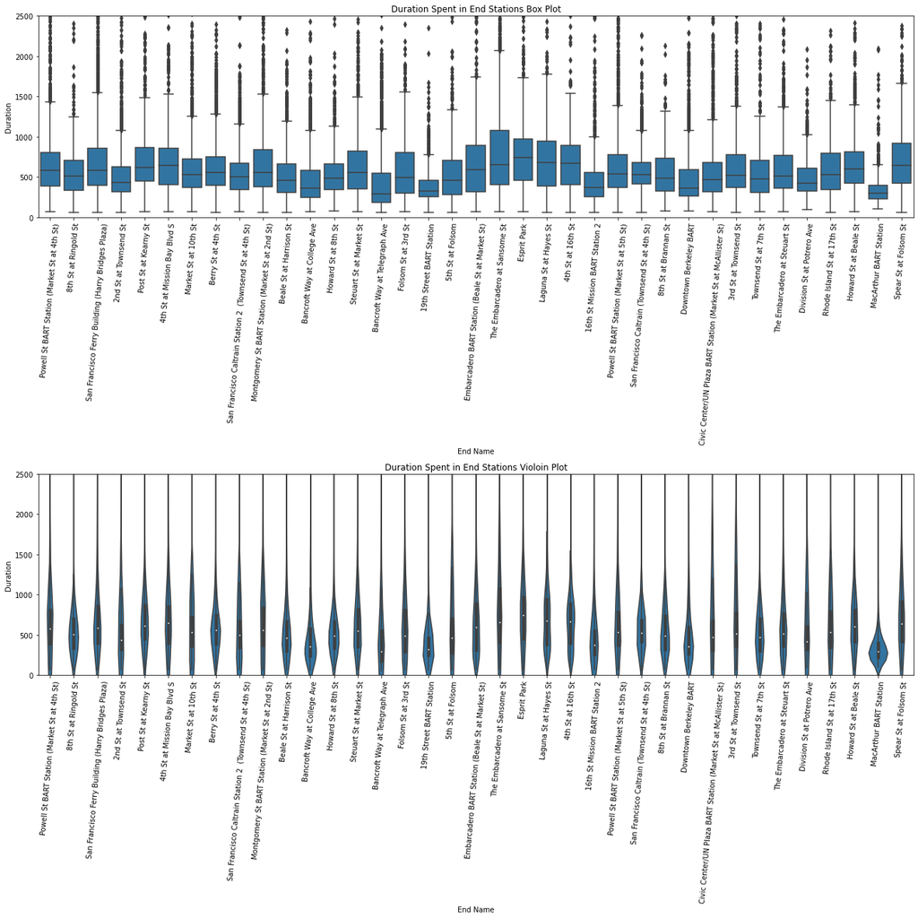

```python
#plotting a violin and box plot for the end stations duration
plt.figure(figsize=[18, 18])
plt.subplot(2, 1, 1)
sb.boxplot(data=end_df, x='end_station_name', y='duration_sec', color=base_color)
plt.ylim(0, 2500)
plt.xticks(rotation=85);
plt.xlabel('End Name');
plt.ylabel('Duration');
plt.title('Duration Spent in End Stations Box Plot');

plt.subplot(2, 1, 2)
sb.violinplot(data=end_df, x='end_station_name', y='duration_sec', color=base_color)
plt.ylim(0, 2500)
plt.xticks(rotation=85);
plt.xlabel('End Name');
plt.ylabel('Duration');
plt.title('Duration Spent in End Stations Violoin Plot');

plt.tight_layout()
```

> From the box plot it can be deduced that The Embarcadero had the highest IQR in terms of duration

> From the violin plot it can be deduced that MacArthur BART had the highest frequency in terms of duration

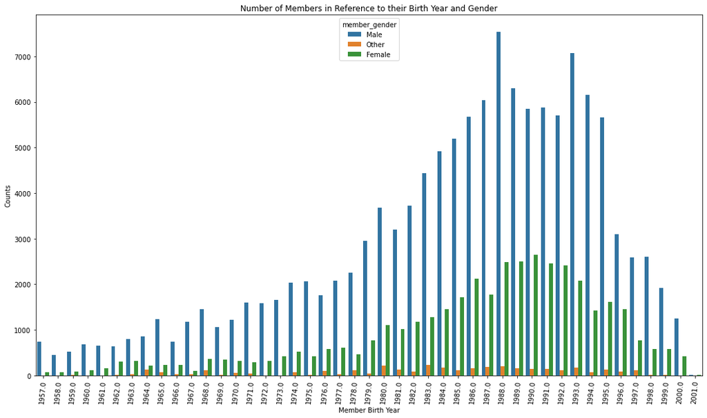

```python
#plotting members' genders by birth years
plt.figure(figsize=[18, 10])
sb.countplot(data=years_df[years_df['member_birth_year'] >= 1957], x='member_birth_year', hue = 'member_gender');
plt.xticks(rotation=85);
plt.xlabel('Member Birth Year');
plt.ylabel('Counts');
plt.title('Number of Members in Reference to their Birth Year and Gender');
```

> From the bar chart above it is clear that men always count more regardless of the birth year

> Also, the highest range was between 1985 and 1995

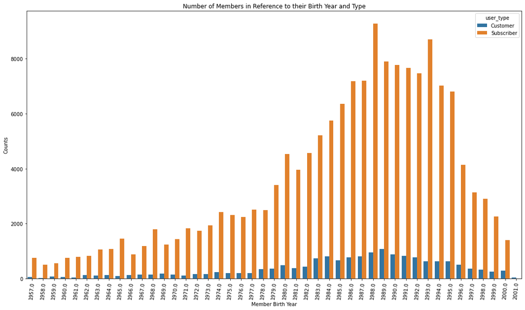

```python
#plotting members' user type by birth years
plt.figure(figsize=[18, 10])
sb.countplot(data=years_df[years_df['member_birth_year'] >= 1957], x='member_birth_year', hue = 'user_type');
plt.xticks(rotation=85);
plt.xlabel('Member Birth Year');
plt.ylabel('Counts');
plt.title('Number of Members in Reference to their Birth Year and Type');
```

> From the bar chart above, it can be observed that the number of subscribers is totally huge compared to the number of customers

> Like the previous graph, it is left skewed, and the highest range is between 1985 to 1995

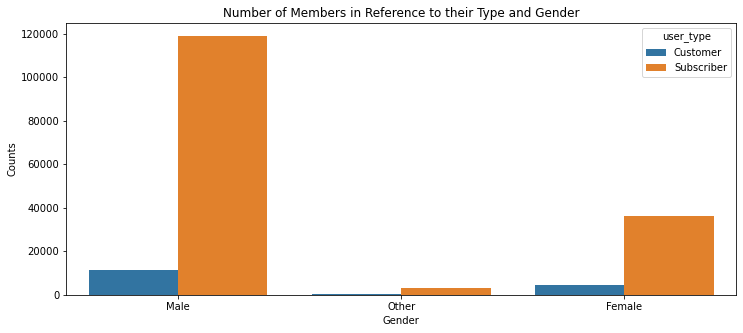

```python
#plotting members gender and their subscription status
plt.figure(figsize=[12, 5])
sb.countplot(data=bikes, x='member_gender', hue = 'user_type');
plt.xlabel('Gender');
plt.ylabel('Counts');
plt.title('Number of Members in Reference to their Type and Gender');
```

> From the above chart it cann be observed that subscribers numbers are always higher, specially with males the proportion is very large

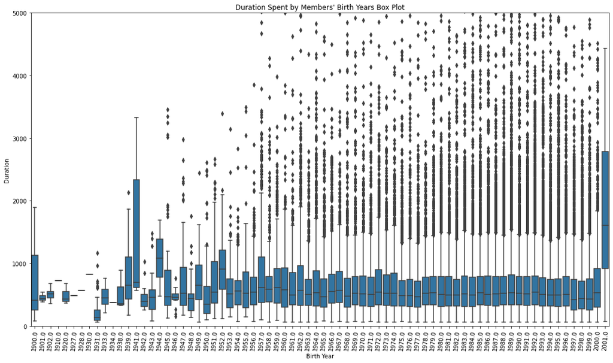

```python
#plotting duration spent by each age category
plt.figure(figsize=[18, 10])
sb.boxplot(data=years_df, x='member_birth_year', y='duration_sec', color=base_color)
plt.ylim(0, 5000)
plt.xticks(rotation=85);
plt.xlabel('Birth Year');
plt.ylabel('Duration');
plt.title("Duration Spent by Members' Birth Years Box Plot");
```

> We can see from the graph above that the highest duration range is in the years 1941 and 2001, however, the 1941 box is more right skewed than the 2001 box.

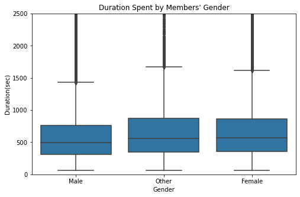

```python
#plotting duration spent by each gender
plt.figure(figsize=[8, 5])
sb.boxplot(data=bikes, x='member_gender', y='duration_sec', color=base_color)
plt.xlabel('Gender');
plt.ylabel('Duration(sec)');
plt.ylim(0,2500);
plt.title("Duration Spent by Members' Gender");
```

> From this graph we can see that all the genders almost have the same IQR in terms of duration, although males are slightly smaller. Same goes for the maximum and minimum points.

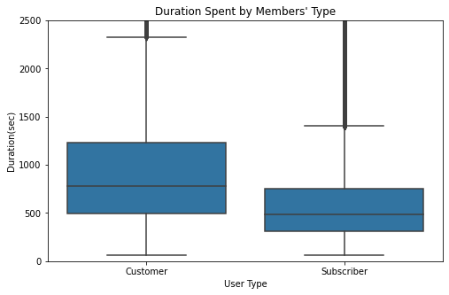

```python
#plotting duration spent by each user type
plt.figure(figsize=[8, 5])
sb.boxplot(data=bikes, x='user_type', y='duration_sec', color=base_color)
plt.xlabel('User Type')
plt.ylabel('Duration(sec)');
plt.ylim(0,2500);
plt.title("Duration Spent by Members' Type");
```

> From this graph we can see that the customers have a larger IQR and higher maximum point in terms of duration compared to that of the subscribers.

### Talk about some of the relationships you observed in this part of the investigation. How did the feature(s) of interest vary with other features in the dataset?

> The Embarcadero had the highest IQR in terms of duration in both the Start and End stations

> Females tend to spend slightly more time

> Members born in the 2000s had the highest IQR in terms of duration

### Did you observe any interesting relationships between the other features (not the main feature(s) of interest)?

> By comparing the gender and the user type features with the birth year feature we can see that:

> > Males were always leading in the usage of bikes regardless of their birth year

> > The proportion of male subscribers is huge, which is logical because the proportion of male users in general is large

## Multivariate Exploration

> Create plots of three or more variables to investigate your data even further. Make sure that your investigations are justified, and follow from your work in the previous sections.

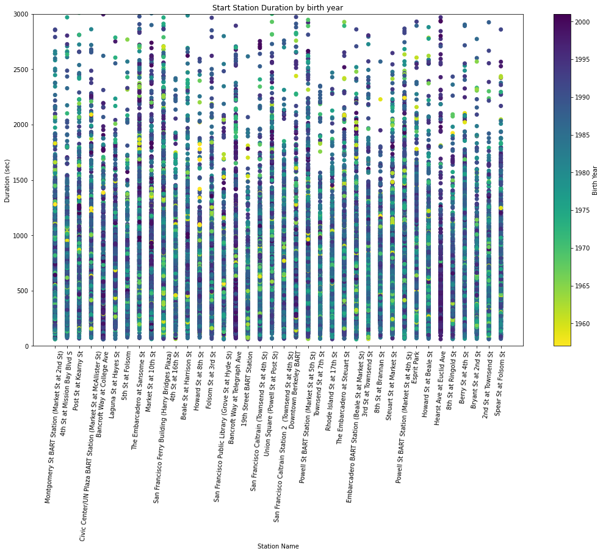

```python
#plotting start stations duration spent by each age category
plt.figure(figsize = [18,10])
plt.scatter(data=start_df[start_df['member_birth_year'] >= 1957], x='start_station_name', y='duration_sec', c='member_birth_year', cmap = 'viridis_r')
plt.title('Start Station Duration by birth year');
plt.xlabel('Station Name');
plt.ylabel('Duration (sec)');
plt.colorbar(label = 'Birth Year');
plt.xticks(rotation=85);
plt.ylim(0,3000);
```

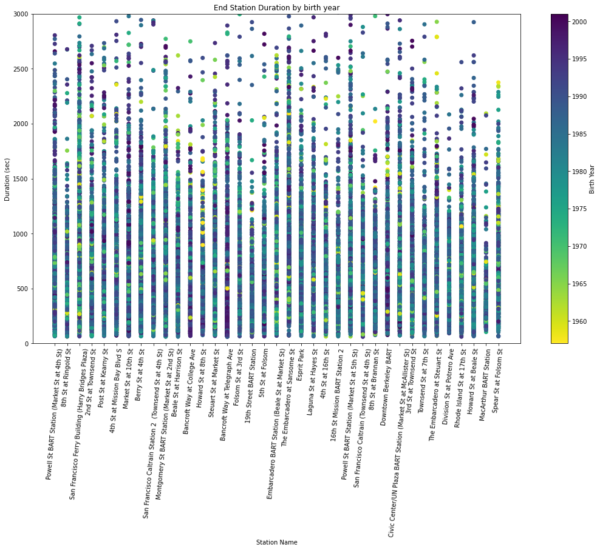

```python
#plotting end stations duration spent by each age category
plt.figure(figsize = [18,10])
plt.scatter(data=end_df[end_df['member_birth_year'] >= 1957], x='end_station_name', y='duration_sec', c='member_birth_year', cmap = 'viridis_r')
plt.title('End Station Duration by birth year');
plt.xlabel('Station Name');
plt.ylabel('Duration (sec)');
plt.colorbar(label = 'Birth Year');
plt.xticks(rotation=85);
plt.ylim(0,3000);
```

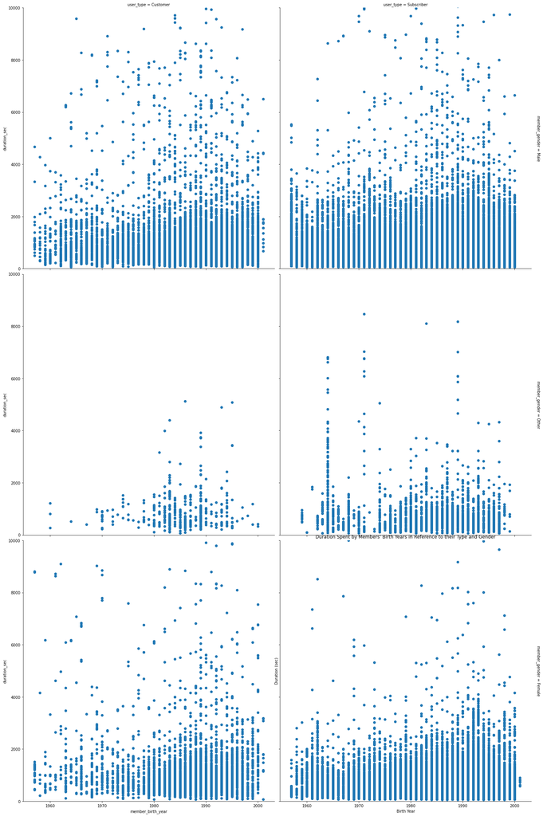

```python
#plotting duration spent by each age category in reference to their gender and user type
g = sb.FacetGrid(data=years_df[years_df['member_birth_year'] >= 1957], col='user_type', row='member_gender', size=10, margin_titles=True);
g.map(plt.scatter, 'member_birth_year', 'duration_sec');
plt.ylim(0,10000);
plt.xlabel('Birth Year');
plt.ylabel('Duration (sec)');
plt.title("Duration Spent by Members' Birth Years in Reference to their Type and Gender");
```

### Talk about some of the relationships you observed in this part of the investigation. Were there features that strengthened each other in terms of looking at your feature(s) of interest?

> The Multivariate plots showed important correlations between features

> > The fisrt and second graphs demonstrates the duration in each station spent by age categories

> > The last plot demonstrates the duration each age category spend in reference to their gender and user type

### Were there any interesting or surprising interactions between features?

> It was interesting that there were some stations that had members with an old age who spent a long duration in it.